# Group_Lasso

Kevin Vo

2/13/2017

# Group Lasso Tutorial

*Note: This tutorial is based off of royr2. I’m using the example and appending my own notes for the sake of my understanding*

## Preprocessing

We first load install the necessary libraries and load them in. We also load in the csv files and format the dates.

```r
library(gglasso)
library(RColorBrewer)
library(zoo)

hist=read.csv("historical_data.csv")
proj=read.csv("projections.csv")

hist=data.frame(Date=as.Date(as.yearqtr(hist[,1])),hist[,-1])
proj=data.frame(Date=proj[,1],proj[,-1])
```

We now make a plot of unemployment rate over time.

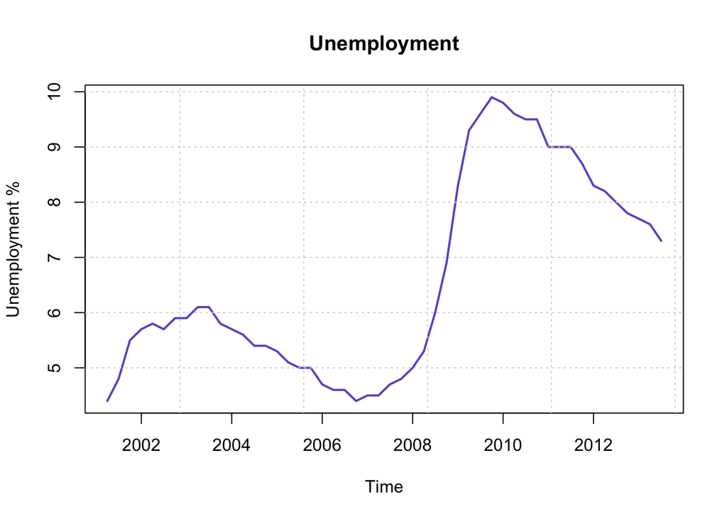

```r
plot(y=hist$Unemployment.Rate,x=hist$Date,main="Unemployment",lwd=2,col="slateblue",type="l",xlab="Time",ylab="Unemployment %")
grid()
```

The data makes sense so far. We expect to see high unemployment during the recession years and a recovery in the following years. Let’s take a look at the column names of the hist data frame.

```r
names(hist)
```

```
##  [1] "Date"
##  [2] "Real.GDP.Growth"
##  [3] "Real.Disposable.Income.Growth"
##  [4] "Unemployment.Rate"
##  [5] "CPI.Inflation.Rate"
##  [6] "X3.Month.Treasury"
##  [7] "X5.Year.Treasury"
##  [8] "X10.Year.Treausry"
##  [9] "BBB.Corporate.Yield"
## [10] "Mortgage.Rate"
## [11] "Prime.Rate"
## [12] "House.Price.Index.pct.chg"
## [13] "Commercial.Real.Estate.Price.Index.pct.chg"
## [14] "Market.Volatility.Index..VIX..pct.chg"
## [15] "Dow.Jones.Total.Stock.Market.Index.pct.chg"
```

We now clean the data a bit. We remove Dates and Unemployment from the model matrix. Here we also define the groups, with the grp vector. Group 1 will be the first three variables. Group 2 will be the next four variables and so fourth.

```r
X=hist[,c(-1,-4)]
X=as.matrix(X)
Y=hist[,4]
grp=c(1,1,1,2,2,2,2,3,3,3,3,4,4)
fit=gglasso(x=X,y=Y,group=grp,loss='ls')
coef.mat=fit$beta
```

Now we identify when the groups enter the model.

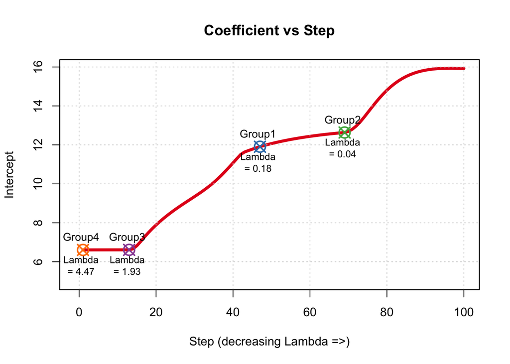

```r
#Group1 enters the equation
g1=max(which(coef.mat[1,]==0))

#Group2 enters the equation
g2=max(which(coef.mat[4,]==0))

#Group3 enters the equation
g3=max(which(coef.mat[8,]==0))

#Group4 enters the equation
g4=max(which(coef.mat[12,]==0))

#Coefficient Plot. Let's also use some nice colors

cols=brewer.pal(5,name="Set1")

plot(fit$b0,main="Coefficient vs Step",
     ylab="Intercept",xlab="Step (decreasing Lambda =>)",
     col=cols[1],
     xlim=c(-1,100),
     ylim=c(5,max(fit$b0)),
     type="l",lwd=4)
grid()
par(new=T)

x=c(g1,g2,g3,g4)
y=c(fit$b0[g1],fit$b0[g2],fit$b0[g3],fit$b0[g4])

plot(x=x,y=y,pch=13,lwd=2,cex=2,col=cols[-1],
     xlim=c(-1,100),ylim=c(5,max(fit$b0)),
     xaxt='n',yaxt='n',xlab="",ylab="")

lmda=round(fit$lambda[c(g1,g2,g3,g4)],2)
text(x=x-0.5,y=y+0.1,labels=c("Group1","Group2","Group3","Group4"),pos=3,cex=0.9)
text(x=x-0.5,y=y-0.1,labels=paste("Lambda\n=",lmda),pos=1,cex=0.8)
```

O.K. here’s the question on the blocks. In a group lasso setting, can variables within a group be zero and nonzero for a given lambda. According to Michael Lim’s Stanford Dissertation he states that “if an estimate $\beta_i$ is nonzero, where $i$ denotes group $i$, then all its components are usually nonzero”. We see this here in “coef.mat”.

```r
coef.mat[, 11:16]
```

```
##                                                     s10          s11
## Real.GDP.Growth                             0.000000000  0.000000000
## Real.Disposable.Income.Growth               0.000000000  0.000000000
## CPI.Inflation.Rate                          0.000000000  0.000000000
## X3.Month.Treasury                           0.000000000  0.000000000
## X5.Year.Treasury                            0.000000000  0.000000000
## X10.Year.Treausry                           0.000000000  0.000000000
## BBB.Corporate.Yield                         0.000000000  0.000000000
## Mortgage.Rate                               0.000000000  0.000000000
## Prime.Rate                                  0.000000000  0.000000000
## House.Price.Index.pct.chg                   0.000000000  0.000000000
## Commercial.Real.Estate.Price.Index.pct.chg  0.000000000  0.000000000
## Market.Volatility.Index..VIX..pct.chg      -0.002389600 -0.002530964
## Dow.Jones.Total.Stock.Market.Index.pct.chg  0.002232569  0.002571568
##                                                     s12          s13
## Real.GDP.Growth                             0.000000000  0.000000000
## Real.Disposable.Income.Growth               0.000000000  0.000000000
## CPI.Inflation.Rate                          0.000000000  0.000000000
## X3.Month.Treasury                           0.000000000  0.000000000
## X5.Year.Treasury                            0.000000000  0.000000000
## X10.Year.Treausry                           0.000000000  0.000000000
## BBB.Corporate.Yield                         0.000000000  0.000000000
## Mortgage.Rate                               0.000000000 -0.003270736
## Prime.Rate                                  0.000000000 -0.005926023
## House.Price.Index.pct.chg                   0.000000000 -0.001951581
## Commercial.Real.Estate.Price.Index.pct.chg  0.000000000 -0.004634945
## Market.Volatility.Index..VIX..pct.chg      -0.002655155 -0.002592666
## Dow.Jones.Total.Stock.Market.Index.pct.chg  0.002952220  0.003267311
##                                                     s14          s15
## Real.GDP.Growth                             0.000000000  0.000000000
## Real.Disposable.Income.Growth               0.000000000  0.000000000
## CPI.Inflation.Rate                          0.000000000  0.000000000
## X3.Month.Treasury                           0.000000000 -0.015718122
## X5.Year.Treasury                            0.000000000 -0.012422527
## X10.Year.Treausry                           0.000000000 -0.008611112
## BBB.Corporate.Yield                         0.000000000 -0.004155207
## Mortgage.Rate                              -0.013331531 -0.019703682
## Prime.Rate                                 -0.023921834 -0.035200299
## House.Price.Index.pct.chg                  -0.007449738 -0.010954105
## Commercial.Real.Estate.Price.Index.pct.chg -0.016527373 -0.022843524
## Market.Volatility.Index..VIX..pct.chg      -0.002238294 -0.001921533
## Dow.Jones.Total.Stock.Market.Index.pct.chg  0.003438297  0.003572838
```

Looking at coef.mat, we see that group 4 stays in the whole the time. Group 3 enters in s13. Group 2 subsequently enters in s15. There are no cases where only a select set of variables from a group enter or exit. They enter and exit as a *group*.

## Group Lasso vs. Lasso

The lasso uses an L1-norm penalty. The L1-norm penalty is defined as
$$S = \sum_{i=1}^n |y_i - f(x_i)|$$
Compare this to the L2-norm penalty. This is probably a loss function that many of you are familiar with. It is defined as follows.
$$S = \sum_{i=1}^n (y_i - f(x_i))^2$$
If you substitute the loss function with L2-norm in lasso you get ridge regression. The grouped lasso minimizes the following convex criterion. Here we have $L$ groups of variables. The feature matrix for group $i$ is denoted by $\textbf{X}$. Let $y$ be the vector of observations. $\beta_j$ for $j = 1, ..., p$. The parameter $\lambda$ controls the amount of regularization, with larger values implying more regularization. When $\lambda$ is large enough, all the coefficients will be estimated as zero. The $\gamma$ allows each group to be penalized to different extents, which allows us to penalize some groups more (or less) than others. Please note that the L2 penalty is not squared.
$$\min_{\beta \in R^p}\frac{1}{2}\big(||y - \beta_0\textbf{1} - \sum_{l= 1}^L\textbf{X}_l\beta_l||_2^2 + \lambda\sum_{l = 1}^L \gamma_l ||\beta_l||_2 \big)$$
Note: Group lasso does not monotonically decrease groups to zero. Groups and enter and exit the model.

Sources

1. http://www.chioka.in/differences-between-l1-and-l2-as-loss-function-and-regularization/
2. http://web.stanford.edu/~hastie/THESES/Michael_Lim.pdf
3. http://royr2.github.io/2014/04/15/GroupLasso.html
4. http://statweb.stanford.edu/~tibs/stat315a/LECTURES/morelasso.pdf